# Homework 5 [PSTAT 131]

### Exercise 3

Create a recipe:

```r
set.seed(3435)

pokemon_split <- initial_split(pokemon, prop = 0.80,
                                strata = type_1) #stratify `survived`
pokemon_train <- training(pokemon_split)
pokemon_test <- testing(pokemon_split)
```

Why might stratifying the folds be useful?

```r
pokemon_fold <- vfold_cv(pokemon_train, v = 5)
```

### Exercise 4

set of recipe:

```r
pokemon_recipe <- recipe(type_1 ~ legendary + generation + sp_atk + attack + speed + defense + hp + sp_def, data = pokemon_train) %>%
  step_dummy(legendary) %>%
  step_dummy(generation) %>%
  step_normalize(all_predictors()) # center and sclae all predictors
```

### Exercise 5

```r
pokemon_spec <- multinom_reg(mode = "classification",
  engine = "glmnet",
  penalty = tune(),
  mixture = tune())

pokemon_wkflow <- workflow() %>%
  add_recipe(pokemon_recipe) %>%
  add_model(pokemon_spec)

pokemon_grid <- grid_regular(penalty(range = c(-5, 5)),mixture(range = c(0,1)), levels = 10)
pokemon_grid
```

```
## # A tibble: 100 × 2
##          penalty mixture
##            <dbl>   <dbl>
##  1      0.00001        0
##  2      0.000129       0
##  3      0.00167        0
##  4      0.0215         0
##  5      0.278          0
##  6      3.59           0
##  7     46.4            0
##  8    599.             0
##  9   7743.             0
## 10 100000              0
## # … with 90 more rows
```

### Exercise 6

Fit the models to your folded data using `tune_grid()`.

Use `autoplot()` on the results. What do you notice? Do larger or smaller values of `penalty` and `mixture` produce better accuracy and ROC AUC?

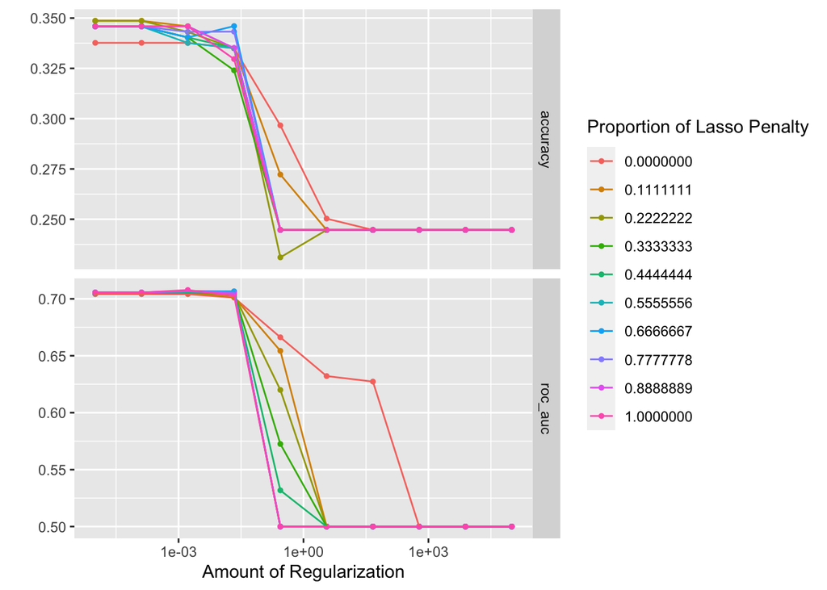

```r
tune_res <- tune_grid(
  pokemon_wkflow,
  resamples = pokemon_fold,
  grid = pokemon_grid
)

autoplot(tune_res)
```

### Exercise 7

Use `select_best()` to choose the model that has the optimal `roc_auc`. Then use `finalize_workflow()`, `fit()`, and `augment()` to fit the model to the training set and evaluate its performance on the testing set.

```r
best_penalty <- select_best(tune_res, metric = "roc_auc")

pokemon_final <- finalize_workflow(pokemon_wkflow, best_penalty)

pokemon_final_fit <- fit(pokemon_final, data = pokemon_train)

augment(pokemon_final_fit, new_data = pokemon_test) %>%
  roc_curve(truth = type_1, estimate = c(.pred_Bug,.pred_Fire, .pred_Grass, .pred_Normal, .pred_Psychic, .pred_Water))
```

```
## # A tibble: 576 × 4
##    .level    .threshold specificity sensitivity
##    <chr>          <dbl>       <dbl>       <dbl>
##  1 Bug    -Inf               0                1
##  2 Bug       0.00000923      0                1
##  3 Bug       0.000154        0.0125           1
##  4 Bug       0.000421        0.025            1
##  5 Bug       0.00203         0.0375           1
##  6 Bug       0.00247         0.05             1
##  7 Bug       0.00373         0.0625           1
##  8 Bug       0.00380         0.075            1
##  9 Bug       0.00686         0.0875           1
## 10 Bug       0.00750         0.1              1
## # … with 566 more rows
```

### Exercise 8

ROC AUC:

```r
augment(pokemon_final_fit, new_data = pokemon_test) %>%
roc_auc(truth = type_1, estimate = c(.pred_Bug,.pred_Fire, .pred_Grass, .pred_Normal, .pred_Psychic, .pred_Water))
```

```
## # A tibble: 1 × 3
##   .metric .estimator .estimate
##   <chr>   <chr>          <dbl>
## 1 roc_auc hand_till      0.692
```

ROC Curve:

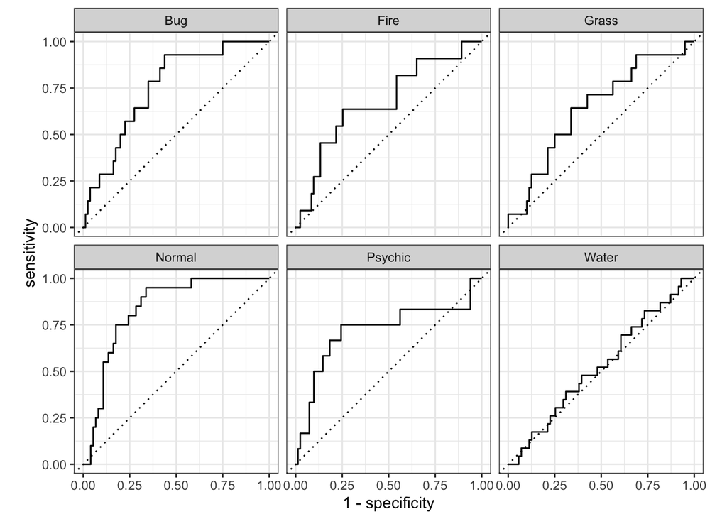

```r
augment(pokemon_final_fit, new_data = pokemon_test) %>%
  roc_curve(truth = type_1, estimate = c(.pred_Bug,.pred_Fire, .pred_Grass, .pred_Normal, .pred_Psychic, .pred_Water)) %>%
  autoplot()
```

Heat map of confusion matrix.

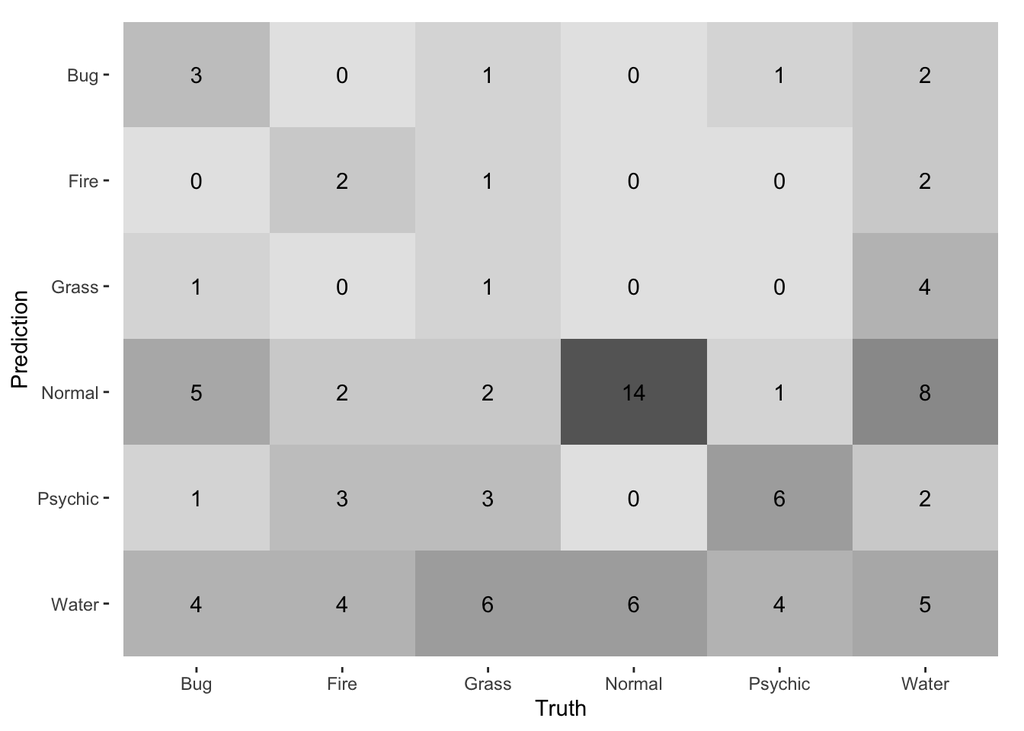

```r
augment(pokemon_final_fit, new_data = pokemon_test) %>%
  conf_mat(truth = type_1, estimate = .pred_class) %>%
  autoplot(type = "heatmap")
```